# Apple Stock Price

John Jacobson

2025-11-21

## Forecasting Apple’s Stock Price Analysis

```r
library(fpp3)
library(ggplot2)
library(tidyverse)
library(tseries)
set.seed(112125)                      # controlled randomness for bootstrapping
```

```r
load("~/Downloads/aapl.rda")
```

## ## 1) Time Series Plot

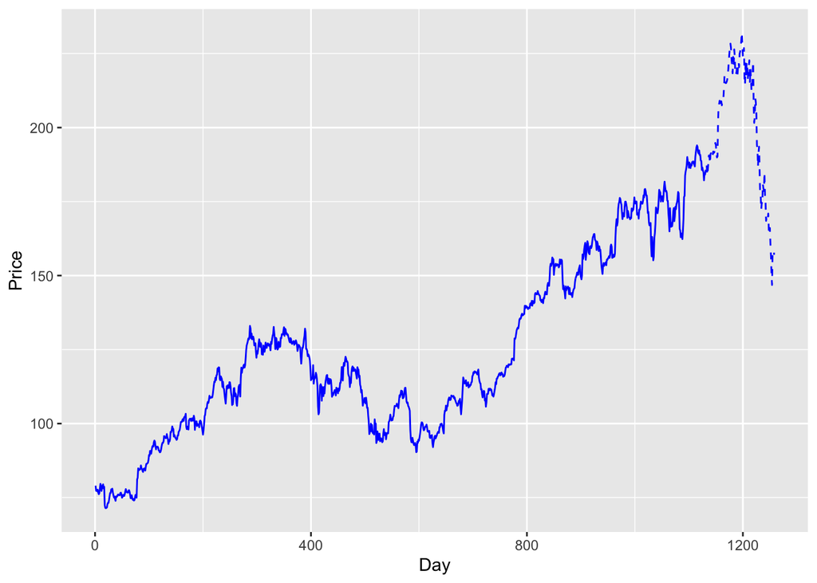

```r
# This splits and then trains and tests
AAPL <- aapl |> mutate(Date = as.Date(Date))
train <- filter(AAPL, Date < as.Date("2018-07-01"))
test <- filter(AAPL, Date >= as.Date("2018-07-01"))

# This plots the price
AAPL_plot <- ggplot() +
  geom_line(aes(Day, Price), data = train, color = 'blue') +
  geom_line(aes(Day, Price), data = test, color = 'blue', linetype = 2)

AAPL_plot
```

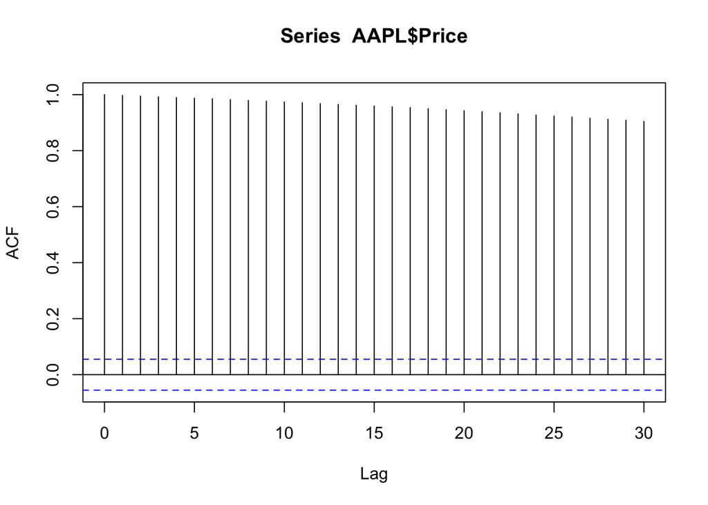

```r
# This runs the ACF and PACF
acf(AAPL$Price)
```

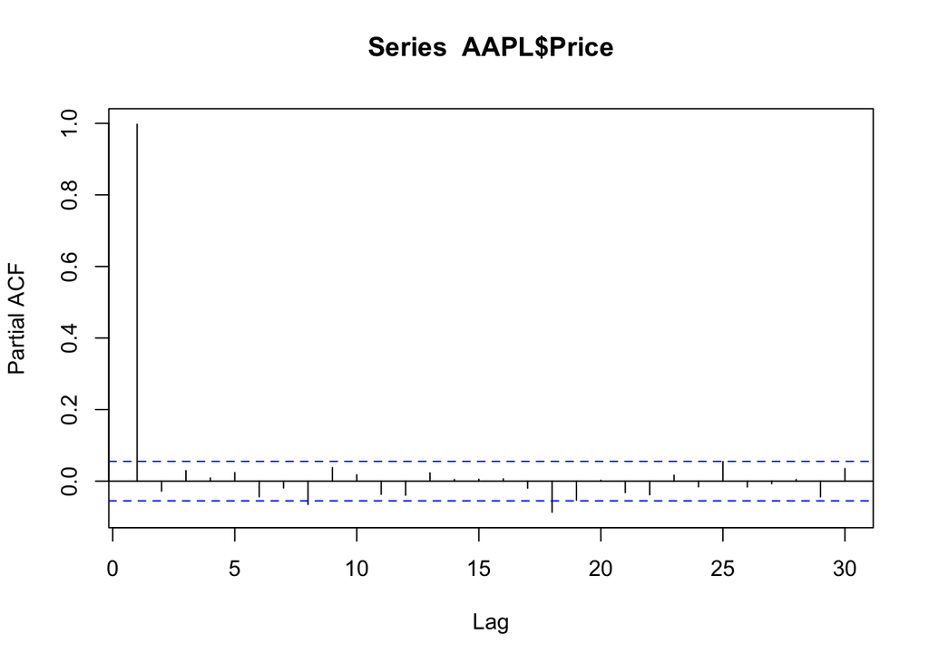

```r
pacf(AAPL$Price)
```

```r
horizon <- nrow(test)
```

When I looked at the time series plot of Apple’s stock price, the first thing I noticed is that the price mostly moves upward over time. It is no flat and it becomes more jumpy toward the end. There’s no real repeating pattern or seasonality that I could see. When I checked the ACF plot, almost every bar was really high, which tells me the data is not stationary and basically acts like a random walk. The PACF plot had one huge spike at lag 1 and then everything else was tiny. Based on these three plots, I learned that the series has a strong trend and a unit root, so models like the random walk or ARIMA with ARIMA(1,1,1) will probably work better.

## ## Simple Forecasts

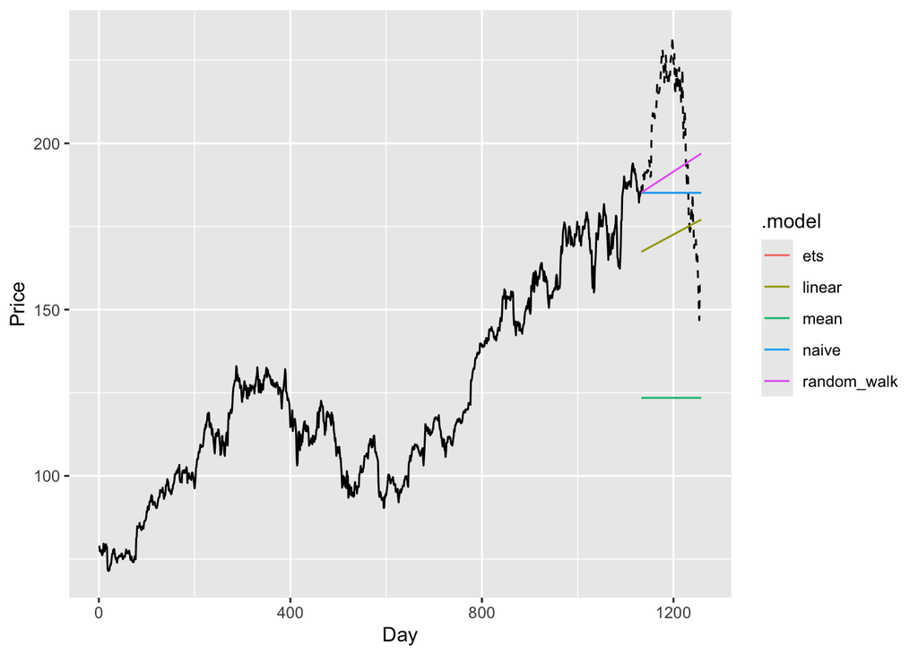

```r
fit_simple <- train |>
  model(
    mean = MEAN(Price),
    naive = NAIVE(Price),
    linear = TSLM(Price ~ trend()),
    random_walk = RW(Price ~ drift()),
    ets = ETS(Price)
  )

fc_simple <- forecast(fit_simple, new_data = test)

ggplot() +
  geom_line(data = train, aes(Day, Price)) +
  geom_line(data = test, aes(Day, Price), linetype = 2) +
  geom_line(data = fc_simple, aes(Day, .mean, color = .model))
```

```r
# This is the in-sample
accuracy(fit_simple) |>
  arrange(RMSE)
```

```
## # A tibble: 5 × 10
##   .model      .type           ME  RMSE   MAE     MPE  MAPE   MASE  RMSSE   ACF1
##   <chr>       <chr>        <dbl> <dbl> <dbl>   <dbl> <dbl>  <dbl>  <dbl>  <dbl>
## 1 random_walk Training -7.54e-16  1.75  1.23 -0.0155  1.01  0.999  0.999 0.0436
## 2 ets         Training  9.37e- 2  1.75  1.23  0.0649  1.01  0.999  1.000 0.0437
## 3 naive       Training  9.38e- 2  1.76  1.23  0.0650  1.01  1      1     0.0436
## 4 linear      Training -9.75e-16 16.0  13.1  -1.64   11.2  10.7    9.13  0.993
## 5 mean        Training  3.55e-15 30.0  24.8  -5.93   20.9  20.1   17.1   0.995
```

```r
# This is the out-of-sample
accuracy(fc_simple, test) |>
  arrange(RMSE)
```

```
## # A tibble: 5 × 10
##   .model      .type    ME  RMSE   MAE   MPE  MAPE  MASE RMSSE  ACF1
##   <chr>       <chr> <dbl> <dbl> <dbl> <dbl> <dbl> <dbl> <dbl> <dbl>
## 1 random_walk Test   10.0  25.3  22.3  3.70  11.1   NaN   NaN 0.967
## 2 ets         Test   16.0  26.9  23.4  6.79  11.3   NaN   NaN 0.965
## 3 naive       Test   16.0  26.9  23.4  6.79  11.3   NaN   NaN 0.965
## 4 linear      Test   28.9  36.9  32.8 13.2   15.7   NaN   NaN 0.966
## 5 mean        Test   77.6  80.6  77.6 37.8   37.8   NaN   NaN 0.965
```

When I compared all the simple forecasting models, it was pretty clear that the random walk model did the best. On the training set, it had the lowest RMSE and MAE, and on the test set it also beat the other models by a decent amount. The mean model and the linear trend model performed pretty badly, especially out-of-sample, and the naive and ETS models were okay but not as good as random walk. Since Apple’s stock price behaves a lot like a random walk, it makes sense that this model ended up being the most accurate. I would choose the random walk model.

## ## Arima Forecasts

```r
adf.test(AAPL$Price)
```

```
##
##  Augmented Dickey-Fuller Test
##
## data:  AAPL$Price
## Dickey-Fuller = -1.858, Lag order = 10, p-value = 0.6384
## alternative hypothesis: stationary
```

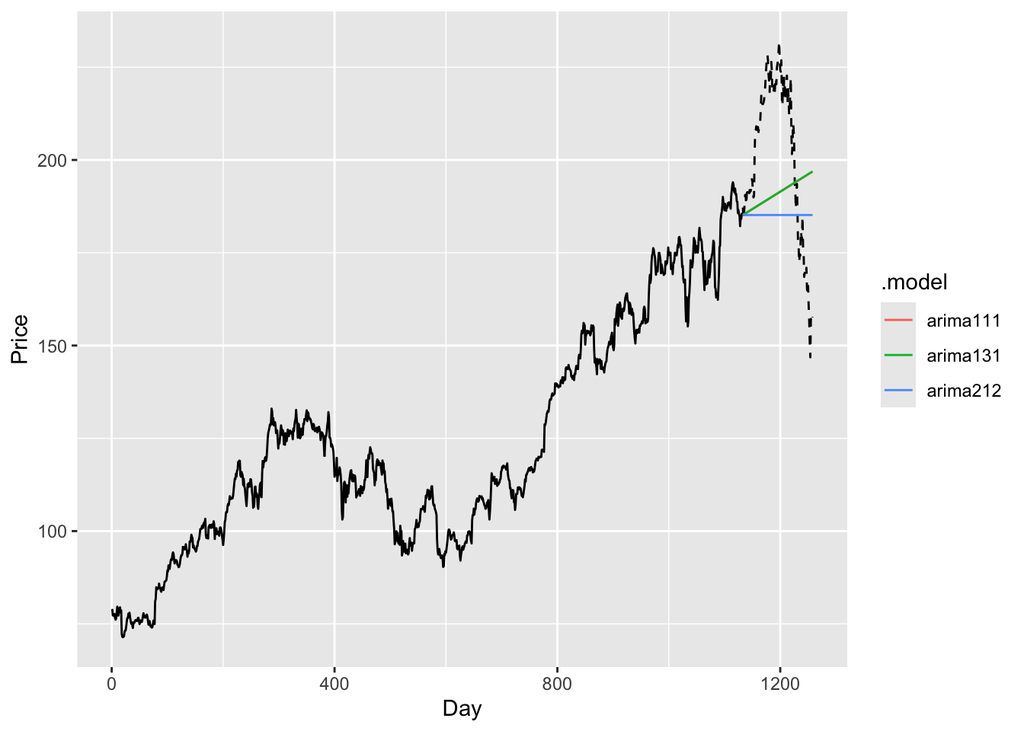

```r
# This fits 3 ARIMA models
fit_arima <- train |>
  model(
    arima111 = ARIMA(Price ~ pdq(1,1,1)),
    arima212 = ARIMA(Price ~ pdq(2,1,2)),
    arima131 = ARIMA(Price ~ pdq(1,1,3))
  )

# This forecasts
fc_arima <- forecast(fit_arima, new_data = test)

# Plot real data + forecasts
ggplot() +
  geom_line(data = train, aes(Day, Price)) +
  geom_line(data = test, aes(Day, Price), linetype = 2) +
  geom_line(data = fc_arima, aes(Day, .mean, color = .model))
```

## ## Bagging

```r
fit_stl <- model(
  train,
  stl = STL(Price)
)

# This generates 20 bootstrapped series
sim_data <- generate(
  fit_stl,
  new_data = train,
  times = 20,
  bootstrap_block_size = 50
) |>
  select(-.model)
# This fits the ARIMA
fc_bag <- sim_data |>
  model(stlarima = ARIMA(.sim)) |>
  forecast(h = horizon) |>
  as.data.frame() |>
  group_by(Day, .rep) |>
  summarize(.mean = mean(.mean), .groups = "drop")
```

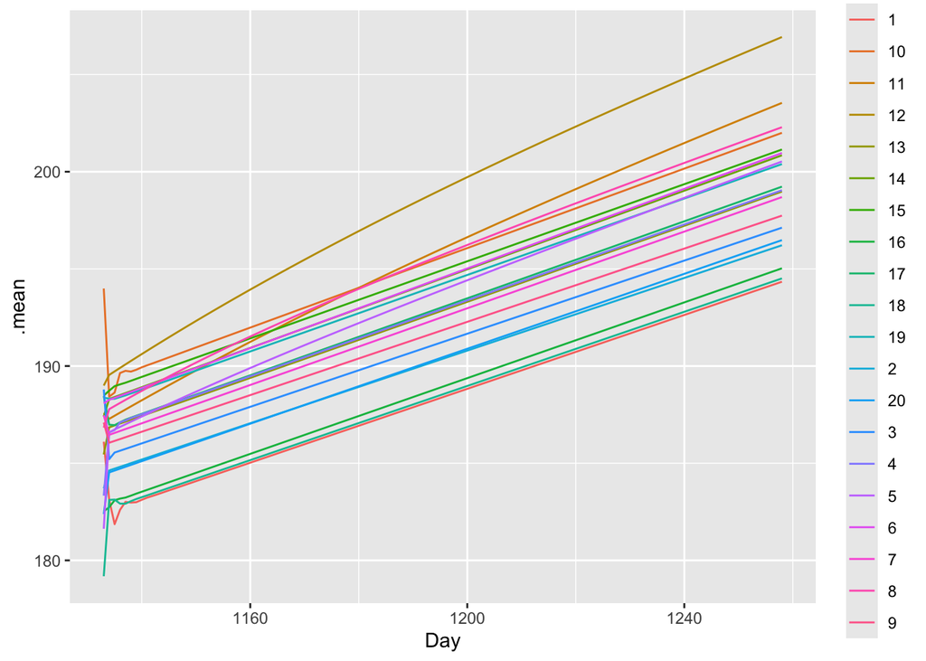

```r
ggplot() +
  geom_line(data = fc_bag, aes(Day, .mean, color = .rep))
```

```r
# This is the average
fc_bag3 <- fc_bag |>
  group_by(Day) |>
  summarize(.mean = mean(.mean), .groups = "drop")

# This compares
compare <- left_join(fc_bag3, test, by = "Day") |>
  select(Day, .mean, Price)

RMSE <- sqrt(mean((compare$.mean - compare$Price)^2))
MAE  <- mean(abs(compare$.mean - compare$Price))

RMSE
```

```
## [1] 24.75056
```

```r
MAE
```

```
## [1] 21.63125
```

## ## Combining Forecasts

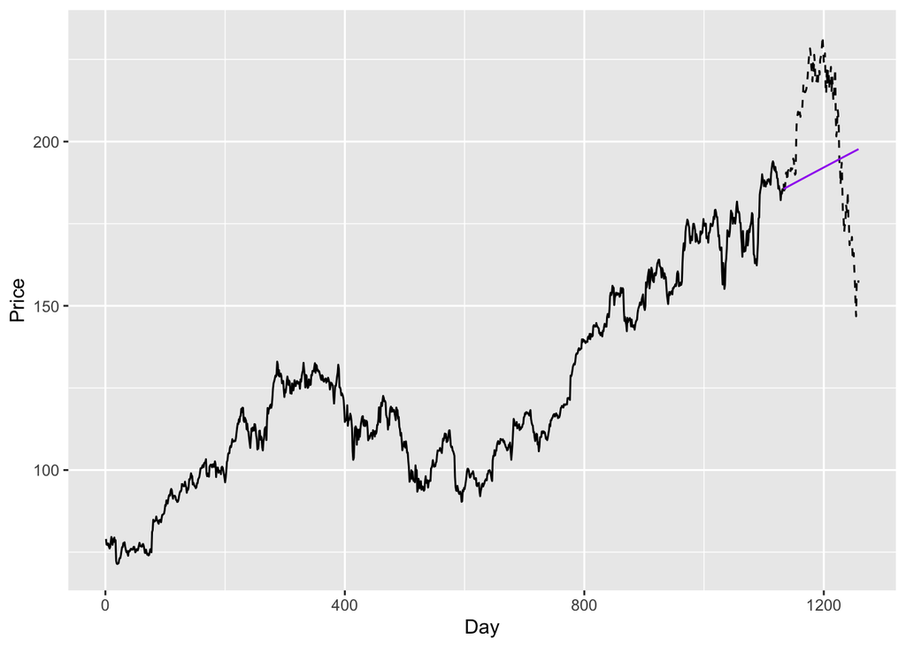

```r
# This picks the best, random walk
best_simple <- fc_simple |>
  filter(.model == "random_walk")

# Pick best ARIMA model arima111
best_arima <- fc_arima |>
  filter(.model == "arima111")

# This combines the average RW + ARIMA + Bagged
fc_combined <- tibble(
  Day = fc_bag3$Day,
  combined = (best_simple$.mean + best_arima$.mean + fc_bag3$.mean) / 3
)

# This plots
ggplot() +
  geom_line(data = train, aes(Day, Price)) +
  geom_line(data = test, aes(Day, Price), linetype = 2) +
  geom_line(data = fc_combined, aes(Day, combined), color = "purple")
```

```r
combined_compare <- left_join(fc_combined, test, by = "Day")

combined_RMSE <- sqrt(mean((combined_compare$combined - combined_compare$Price)^2))
combined_MAE  <- mean(abs(combined_compare$combined - combined_compare$Price))

combined_RMSE
```

```
## [1] 25.10596
```

```r
combined_MAE
```

```
## [1] 22.07206
```

After combining the random walk model, the ARIMA(1,1,1) model, and the bagged forecast, I checked the accuracy and found that the combined model had an RMSE of about 25.1 and an MAE of about 22.1. These numbers were not better than the best individual model from before, which means the combined forecast didn’t actually improve the predictions in this case. Even though the combined line looked smooth on the plot, the accuracy shows that it wasn’t more accurate overall.

## ## Full Forecast

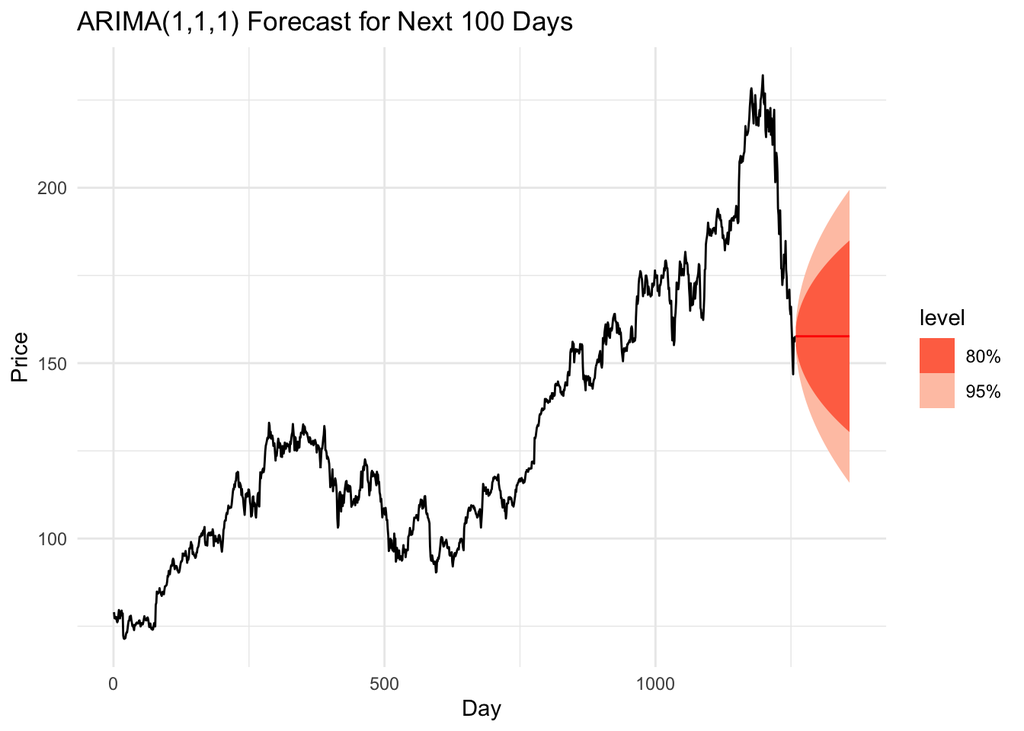

```r
# This fits the best ARIMA model on the full data
fit_full <- AAPL |>
  model(arima111 = ARIMA(Price ~ pdq(1,1,1)))

# This forecasts the next 100 days
fc_full <- forecast(fit_full, h = 100)

# This plots the actual data + forecast using autolayer
aapl |>
  ggplot(aes(Day, Price)) +
  geom_line() +
  autolayer(fc_full, color = "red") +
  labs(title = "ARIMA(1,1,1) Forecast for Next 100 Days",
       y = "Price", x = "Day") +
  theme_minimal()
```